# NYTimes Web APIs

Coffy Andrews-Guo

21 October, 2021

Source: [GitHub](https://github.com/candrewxs/D607_WebAPIs/blob/main/Books.Rmd) [RPubs](https://rpubs.com/blesned/nytimes)

## Load packages

```r
library("tidyverse")
library("httr")
library("reactable")
library("jsonlite")
library("tibble")
```

## Make a request to the API Server

In this assignment, The New York Times, JSON data was pulled using the Developer zone Book API on their Best Sellers list https://developer.nytimes.com/apis. A request for data with a GET function and returned a list containing all of the information from the API server.

```r
nybk <- GET("https://api.nytimes.com/svc/books/v3/lists/names.json?api-key=mRnATzHBDOaywjgsvH9402TBMw8RhxEG")
```

A summary provides a “Status” on the success or failure of the API request, and it comes in the form of a number. A desired number 200 corresponds to a successful request. The content type indicates what form the data takes and this response has the data in a json format.

```r
nybk      # summary look at the resulting response
```

```
## Response [https://api.nytimes.com/svc/books/v3/lists/names.json?api-key=mRnATzHBDOaywjgsvH9402TBMw8RhxEG]
##   Date: 2021-10-21 20:04
##   Status: 200
##   Content-Type: application/json; charset=UTF-8
##   Size: 12.5 kB
```

## Parsing Data

The NYTimes Book API Best Sellers content list is converted from a raw vector to a character. The `fromJSON` function combined with `rawToChar` function will parse the JSON file, convert the raw vector to a character, and create a data set. We will use `names` command to provide a list of the data set list elements.

```r
rawToChar(nybk$content)  # convert raw vector to character vector objects
```

```r
nybook <- fromJSON(rawToChar(nybk$content))

names(nybook)   # returns list names
```

```
## [1] "status"      "copyright"   "num_results" "results"
```

We will analyze the `results list` for it contains a nested hierarchical data structure with 59 observations and 6 variables. The `flatten()` function from `jsonlite` package assigned each of the variables as its own column.

```r
nybks_flat <- flatten(nybook$results)

str(nybks_flat)
```

```
## 'data.frame':    59 obs. of  6 variables:
##  $ list_name            : chr  "Combined Print and E-Book Fiction" "Combined Print and E-Book Nonfiction" "Hardcover Fiction" "Hardcover Nonfiction" ...
##  $ display_name         : chr  "Combined Print & E-Book Fiction" "Combined Print & E-Book Nonfiction" "Hardcover Fiction" "Hardcover Nonfiction" ...
##  $ list_name_encoded    : chr  "combined-print-and-e-book-fiction" "combined-print-and-e-book-nonfiction" "hardcover-fiction" "hardcover-nonfiction" ...
##  $ oldest_published_date: chr  "2011-02-13" "2011-02-13" "2008-06-08" "2008-06-08" ...
##  $ newest_published_date: chr  "2021-10-31" "2021-10-31" "2021-10-31" "2021-10-31" ...
##  $ updated              : chr  "WEEKLY" "WEEKLY" "WEEKLY" "WEEKLY" ...
```

Converting the data frame to a table and show only the first 10 variables with data type.

```r
nybooks_tbl <- as.data.frame(nybks_flat) # convert data frame to a table data frame
names(nybooks_tbl) <- toupper(names(nybooks_tbl))  # convert the data frame names to uppercase

reactable(nybooks_tbl)
```

| LIST_NAME | DISPLAY_NAME | LIST_NAME_ENCODED | OLDEST_PUBLISHED_DATE | NEWEST_PUBLISHED_DATE | UPDATED |
| --- | --- | --- | --- | --- | --- |
| Combined Print and E-Book Fiction | Combined Print & E-Book Fiction | combined-print-and-e-book-fiction | 2011-02-13 | 2021-10-31 | WEEKLY |
| Combined Print and E-Book Nonfiction | Combined Print & E-Book Nonfiction | combined-print-and-e-book-nonfiction | 2011-02-13 | 2021-10-31 | WEEKLY |
| Hardcover Fiction | Hardcover Fiction | hardcover-fiction | 2008-06-08 | 2021-10-31 | WEEKLY |
| Hardcover Nonfiction | Hardcover Nonfiction | hardcover-nonfiction | 2008-06-08 | 2021-10-31 | WEEKLY |
| Trade Fiction Paperback | Paperback Trade Fiction | trade-fiction-paperback | 2008-06-08 | 2021-10-31 | WEEKLY |
| Mass Market Paperback | Paperback Mass-Market Fiction | mass-market-paperback | 2008-06-08 | 2017-01-29 | WEEKLY |
| Paperback Nonfiction | Paperback Nonfiction | paperback-nonfiction | 2008-06-08 | 2021-10-31 | WEEKLY |
| E-Book Fiction | E-Book Fiction | e-book-fiction | 2011-02-13 | 2017-01-29 | WEEKLY |
| E-Book Nonfiction | E-Book Nonfiction | e-book-nonfiction | 2011-02-13 | 2017-01-29 | WEEKLY |
| Hardcover Advice | Hardcover Advice & Misc. | hardcover-advice | 2008-06-08 | 2013-04-21 | WEEKLY |

[output cut: 49 more lines]

## Analysis

Load packages for analysis and visualization

```r
library("dplyr")
library("ggplot2")
library("stringr")
```

Extract sub strings in a character vector to analyze `best selling books against the newest published date`.

```r
Year <- substr(nybooks_tbl$NEWEST_PUBLISHED_DATE, 1, 4 )
Month <- substr(nybooks_tbl$NEWEST_PUBLISHED_DATE, 6, 7)
Date <- substr(nybooks_tbl$NEWEST_PUBLISHED_DATE, nchar(nybooks_tbl$NEWEST_PUBLISHED_DATE) - 2 + 1, nchar(nybooks_tbl$NEWEST_PUBLISHED_DATE))
```

Combine the substrings into a data frame.

```r
df <- cbind.data.frame(Year, Month, Date)

plot1 <- df %>%
  group_by(Year) %>%
  summarise (Count = n()) %>%
  arrange(desc(Year))

plot1
```

```
## # A tibble: 7 x 2
##   Year  Count
##   <chr> <int>
## 1 2021     18
## 2 2019      2
## 3 2017     28
## 4 2016      1
## 5 2015      2
## 6 2013      6
## 7 2012      2
```

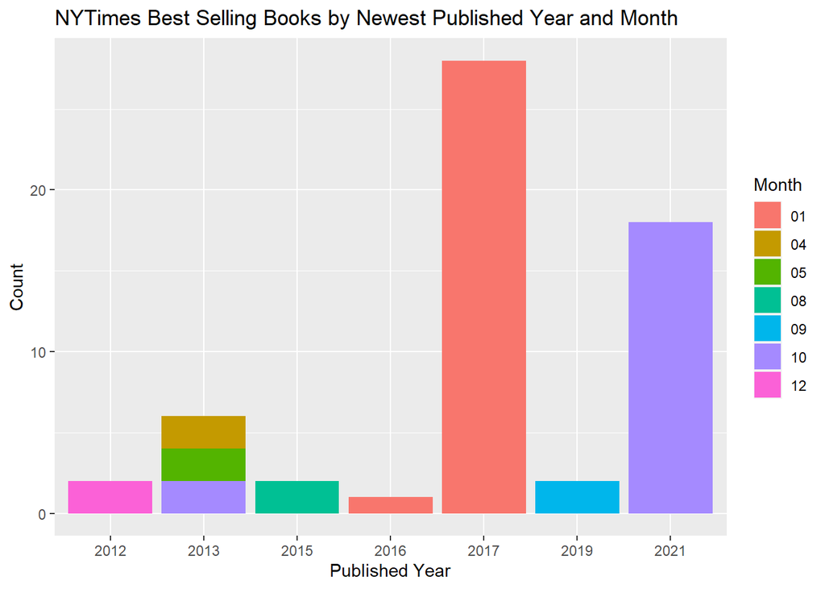

```r
ggplot(df) +
  geom_bar(aes(Year, fill = Month)) +
 labs(x = "Published Year", y = "Count",
     title = "NYTimes Best Selling Books by Newest Published Year and Month")
```

## Conclusion

In this assignment, NYTimes Developers API’s, had a successful connection with `GET() function` to retrieve NYT Best Sellers Lists. A analysis was performed on `What year the Best Selling Books were published?`. The results showed a range between 2012 to 2021 and only three years (2014, 2018, and 2020) where a best selling book was not present. Although, these results are dynamic because the dataset is updated weekly and monthly.